# Third Week: Exploratory Data Analysis

LaLiga Analysis

Mohammadmahdi Faryabi - STD-ID: 93101951

2018-02-27 01:47:30

# تمرین سری سوم: از لالیگا تا لیگ برتر

> با استفاده از داده های لیگ دسته اول اسپانیا به سوالات زیر پاسخ دهید. از هر دو ابزار ggplot2 و highcharter برای این کار تصویرسازی استفاده نمایید.

> Assumption: The above sentense means that both packages should be used overally in this assignment.  
> Every package has its own power and weakness points. Highcharter is not suitable for big data and does not provide extreme levels of customizations as ggplot provides, for example highcharter does not have the ability to add trendlines to charts!  
> In another way highcharter plots are more beautiful and pleasing to eye.  
> So in conclution. some questions are answered using highcharter and some using ggplot2.

Adding required packages and loading data:

```r
library(engsoccerdata)
library(dplyr)
library(tidyr)
library(ggplot2)
library(cowplot)
library(highcharter)
library(magrittr)
library(xtable)
fdb <- as.tbl(spain) # as.tbl is a function defined in dplyr package!
# what about season 1986 phase2? we igonre it!
fdb %>% filter(round != 'phase2') -> fdb
```

۱. تعداد قهرمانی های تیم ها در تاریخ لالیگا را استخراج کرده و نمودار ستونی آنها را رسم کنید.

```r
################################################################################################
# Q1

rbind(
  fdb %>% select(Date, Season, team = home, opp = visitor, GS = hgoal, GR = vgoal),
  fdb %>% select(Date, Season, team = visitor, opp = home, GS = vgoal, GR = hgoal)
) -> team_results
team_results %>% group_by(team, Season) %>%
  summarise(PTS = sum(GS > GR) * 3 + sum(GS == GR), GS = sum(GS), GR = sum(GR)) -> team_points
# sounds like the order of summarise is important
team_points %>% group_by(Season) %>% top_n(1, PTS) %>% arrange(Season) %>%
  mutate(GB = GS - GR) %>% group_by(Season) %>% top_n(1, GB) -> season_champions
# some Seasons, top teams have the same score
# using goal balance to determine champion
season_champions %>% group_by(team) %>% summarise(championships = n()) %>% arrange(desc(championships)) -> team_champs
team_champs %>% hchart(type = 'column', hcaes(x = team, y = championships))
```

[interactive chart not shown]

```r
# OMG! only 8 teams have ever won the laliga!
# hcaes := HighCharterAES hcaes
```

۲. کسل کننده ترین لیگ و تیم را بیابید. نمودار ده تیم و ده فصل کسل کننده را رسم کنید.

In order ro find the most boring Seasons and teams one should define a game bordom factor.  
This factor is defined as followed:

```r
################################################################################################
# Q2 _ the most boring leagues

# find team count for each league
team_results %>% group_by(Season) %>% distinct(team) %>% summarise(team_count = n()) -> season_teams

fdb %>% mutate(goals = hgoal + vgoal) %>% group_by(Season) %>% summarise(goals = sum(goals)) %>%
  arrange(Season) -> season_goals

season_data <- full_join(season_teams, season_goals)
```

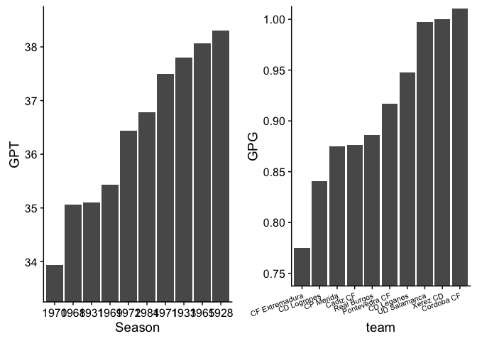

```r
season_data %>% mutate(GPT = goals/team_count) %>% arrange(GPT) %>% slice(1:10) -> data_2_1 # Goals Per Team

data_2_1$Season <- factor(data_2_1$Season, levels = data_2_1$Season)
data_2_1 %>% ggplot(aes(x = Season, y = GPT)) + geom_col() + coord_cartesian(ylim = c(33.5, 38.5)) -> plot_2_1

################################################################################################
# Q2 _ the most boring teams

team_results %>% group_by(team) %>% summarise(team_goals = sum(GS), team_games = n()) %>%
  mutate(GPG = team_goals/team_games) %>% arrange(GPG) %>% slice(1:10) -> data_2_2 # Goals Per Game
data_2_2$team <- factor(data_2_2$team, levels = data_2_2$team)

data_2_2 %>% ggplot(aes(x = team, y = GPG)) + geom_col() + coord_cartesian(ylim = c(0.75, 1)) +
  theme(axis.text.x = element_text(angle = 20, hjust = 1, size = 8)) -> plot_2_2

################################################################################################
# Q2 _ result

plot_grid(plot_2_1, plot_2_2)
```

۳. در چند درصد موارد قهرمان نیم فصل در پایان فصل قهرمان شده است؟

In order to find the half season champion per season, I’ve sorted season games by date and cut them in half, then calculated the champion based on half of the games.

```r
################################################################################################
# Q3

team_results %>% group_by(Season) %>% arrange(Date) %>% slice(1:(n() %/% 2)) -> half_season_resluts
half_season_resluts %>% group_by(team, Season) %>%
  summarise(PTS = sum(GS > GR)*3 + sum(GS==GR), GS = sum(GS), GR = sum(GR)) %>%
  group_by(Season) %>% arrange(desc(PTS)) %>% top_n(1, PTS) %>% mutate(GB=GS-GR) %>% arrange(desc(GB)) %>%
  top_n(1, GB) %>% arrange(desc(GS)) %>% top_n(1, GS) -> mid_season_champions

# season_champions %>% View()
# mid_season_champions %>% View()

full_join(season_champions, mid_season_champions, by = "Season") %>%
  mutate(champion_stay_status = team.x == team.y) %$% mean(.$champion_stay_status) %>% print()
```

```
## [1] 0.5116279
```

۴. در بین سال های ۲۰۰۱ تا ۲۰۱۰ گربه سیاه تیم های بزرگ چه تیم هایی بوده است؟

In order to define a ‘gorbe-siah factor :)’ I’ve calculated multiple statistics.  
Average team ranking in the period of study per team,  
Average goal balance in the period of study per team,  
Average points scored in the period of study per team.

Then I’ve normalized this factores and set their maximum effective value to 1 so a team can get at most 1 from each of these factors (3 in total).

This overall sum is power factor of teams. starting at 0 and ending at 3.

a ‘gorbeh-siah’ factor is calculated for every ordered touple of teams. first team is the affected team and second is effecting team.  
The fector is calculated by deviding the power factor of affected team by power factor of effecting team and the multiplied by number of bad lucks for this touple.  
Number of bad lucks is total number of times an affected team was unable to win an effecting team (draws and loses matter).

At the end top 20 touples were reported.

```r
################################################################################################
# Q4

team_results %>% filter(Season >= 2001 & Season <= 2010) %>% group_by(team) %>% filter(GS <= GR) %>%
  group_by(team, opp) %>% summarise(bad_lucks = n()) -> bad_lucks

team_results %>% filter(Season >= 2001 & Season <= 2010) %>% group_by(team) %>%
  summarise(mean_gb = (sum(GS) - sum(GR))/n(), mean_pts = (sum(GS > GR)*3 + sum(GS==GR))/n()) -> mean_pts_gb

LEAGUE_SIZE <- 20

team_results %>% filter(Season >= 2001 & Season <= 2010) %>% group_by(Season, team) %>%
  summarise(PTS = sum(GS > GR)*3 + sum(GS==GR), GS = sum(GS), GR = sum(GR)) %>% arrange(desc(PTS)) %>%
  mutate(rank = 1:n()) %>% group_by(team) %>% summarise(mean_rank = LEAGUE_SIZE - mean(rank)) -> mean_rank

full_join(mean_pts_gb, mean_rank, by = "team") %>%
  mutate(power_rank = mean_pts/max(mean_pts) + (mean_gb - min(mean_gb))/(max(mean_gb) - min(mean_gb)) + mean_rank/max(mean_rank)) %>%
  arrange(desc(power_rank)) %>% select(team, power_rank) -> power_ranks

full_join(bad_lucks, power_ranks, by = "team") %>% full_join(power_ranks, by = c("opp" = "team")) %>%
  mutate(gorbeh_siah_factor = power_rank.x/power_rank.y*bad_lucks) %>% arrange(desc(gorbeh_siah_factor)) %>%
  ungroup() %>% slice(1:20) %>% print()
```

```
## # A tibble: 20 x 6
##    team      opp      bad_lucks power_rank.x power_rank.y gorbeh_siah_fac…
##    <chr>     <chr>        <int>        <dbl>        <dbl>            <dbl>
##  1 Valencia… Racing …        12         2.38         1.26             22.6
##  2 FC Barce… CA Osas…        10         2.99         1.38             21.6
##  3 Sevilla … CA Osas…        13         2.15         1.38             20.2
##  4 Deportiv… RCD Mal…        15         1.84         1.45             19.0
##  5 Villarre… CA Osas…        13         1.98         1.38             18.6
##  6 Sevilla … Malaga …        11         2.15         1.33             17.8
##  7 FC Barce… Real Be…         9         2.99         1.53             17.6
##  8 Sevilla … Deporti…        15         2.15         1.84             17.5
##  9 FC Barce… Espanyo…         8         2.99         1.38             17.3
## 10 Valencia… CA Osas…        10         2.38         1.38             17.2
## 11 Villarre… Espanyo…        12         1.98         1.38             17.2
## 12 FC Barce… Atletic…        11         2.99         1.92             17.1
## 13 Sevilla … Racing …        10         2.15         1.26             17.0
## 14 Real Mad… CA Osas…         8         2.93         1.38             17.0
## 15 Atletico… Espanyo…        12         1.92         1.38             16.7
## 16 Athletic… Espanyo…        14         1.62         1.38             16.4
## 17 Sevilla … RCD Mal…        11         2.15         1.45             16.3
## 18 Real Mad… Real Za…         7         2.93         1.26             16.2
## 19 Real Mad… RCD Mal…         8         2.93         1.45             16.1
## 20 Valencia… Athleti…        11         2.38         1.62             16.1
```

۵. در تاریخ لالیگا کدام تیم رکورددار زودترین قهرمانی است؟ همچنین کدام تیم مقتدرانه ترین قهرمانی را داشته است؟

A powerfull championship is a championship with high score gap between champion team and its direct chaser.

```r
################################################################################################
# Q5_a

full_join(team_results, season_teams, by = "Season") %>% arrange(Date) %>% group_by(Season) %>%
  mutate(week_index = (0:(n()-1) %/% team_count) + 1) %>% group_by(week_index) -> week_data

week_data %>% mutate(rem_weeks = (team_count-1)*2-week_index) -> week_data

# week_data %>% View()

week_data %>% mutate(PTS = (GS > GR) * 2 + (GS >= GR)) %>%
  group_by(Season, team) %>% arrange(Date) %>% mutate(tot_PTS = cumsum(PTS)) -> week_data

week_data %>% ungroup() %>% group_by(Season, week_index) %>% arrange(desc(tot_PTS)) %>% slice(2) %>%
  select(Season, week_index, second_pts = tot_PTS) -> second_pts_by_week

full_join(week_data, second_pts_by_week) -> week_data_with_second_places
week_data_with_second_places %>% ungroup() %>%  group_by(Season, week_index) %>% arrange(desc(tot_PTS)) %>%
  mutate(champion = (rem_weeks * 3) < (tot_PTS - second_pts) ) -> champion_status

champion_status %>% filter(champion == TRUE) %>% group_by(Season) %>% arrange(desc(rem_weeks)) %>%
  top_n(1, rem_weeks) %>% select(Season, team, rem_weeks) %>% ungroup() %>% slice(1:10) %>% print()
```

```
## # A tibble: 10 x 3
##    Season team         rem_weeks
##     <dbl> <chr>            <dbl>
##  1   1990 FC Barcelona      5.00
##  2   2004 FC Barcelona      5.00
##  3   1960 Real Madrid       5.00
##  4   1973 FC Barcelona      5.00
##  5   1974 Real Madrid       5.00
##  6   1962 Real Madrid       5.00
##  7   1987 Real Madrid       4.00
##  8   1989 Real Madrid       4.00
##  9   1985 Real Madrid       4.00
## 10   1997 FC Barcelona      4.00
```

```r
################################################################################################
# Q5_b
# the most perfect championship is interpreted as the most difference gap between champion and its first chaser

team_points %>% group_by(Season) %>% arrange(desc(PTS)) %>% slice(2) %>% arrange(Season) %>%
  mutate(GB = GS - GR) -> season_second_champions

full_join(
  season_champions %>% select(Season, team_1 = team, PTS_1 = PTS, GB_1 = GB),
  season_second_champions %>% select(Season, team_2 = team, PTS_2 = PTS, GB_2 = GB),
  by = 'Season'
) %>% mutate(pts_gap = PTS_1 - PTS_2, gb_gap = GB_1 - GB_2) %>% arrange(desc(pts_gap)) %>% ungroup() %>%
  slice(1:10) -> champion_pts_gap

champion_pts_gap %>% print()
```

```
## # A tibble: 10 x 9
##    Season team_1       PTS_1  GB_1 team_2       PTS_2  GB_2 pts_gap gb_gap
##     <dbl> <chr>        <dbl> <int> <chr>        <dbl> <int>   <dbl>  <int>
##  1   1962 Real Madrid   72.0    50 Atletico Ma…  51.0    25    21.0     25
##  2   1960 Real Madrid   76.0    64 Atletico Ma…  57.0    22    19.0     42
##  3   1985 Real Madrid   82.0    50 FC Barcelona  63.0    25    19.0     25
##  4   1974 Real Madrid   70.0    32 Real Zarago…  53.0    11    17.0     21
##  5   1987 Real Madrid   90.0    69 Real Socied…  73.0    28    17.0     41
##  6   1990 FC Barcelona  82.0    41 Real Madrid   66.0    26    16.0     15
##  7   1984 FC Barcelona  74.0    44 Atletico Ma…  59.0    23    15.0     21
##  8   2012 FC Barcelona 100      75 Real Madrid   85.0    61    15.0     14
##  9   1989 Real Madrid   88.0    69 FC Barcelona  74.0    44    14.0     25
## 10   1968 Real Madrid   65.0    25 UD Las Palm…  53.0    11    12.0     14
```

```r
champion_pts_gap %>% hchart(type = 'column', hcaes(x = team_1, y = pts_gap))
```

[interactive chart not shown]

۶. طولانی ترین نوار پیروزی مساوی و شکست مال چه تیم هایی است؟